# Self-Driving Car Engineer Nanodegree

## Project: Build a Traffic Sign Recognition Classifier

In this notebook, a template is provided for you to implement your functionality in stages which is required to successfully complete this project. If additional code is required that cannot be included in the notebook, be sure that the Python code is successfully imported and included in your submission, if necessary. Sections that begin with **'Implementation'** in the header indicate where you should begin your implementation for your project. Note that some sections of implementation are optional, and will be marked with **'Optional'** in the header.

In addition to implementing code, there will be questions that you must answer which relate to the project and your implementation. Each section where you will answer a question is preceded by a **'Question'** header. Carefully read each question and provide thorough answers in the following text boxes that begin with **'Answer:'**. Your project submission will be evaluated based on your answers to each of the questions and the implementation you provide.

> **Note:** Code and Markdown cells can be executed using the **Shift + Enter** keyboard shortcut. In addition, Markdown cells can be edited by typically double-clicking the cell to enter edit mode.

## Step 1: Dataset Exploration

Visualize the German Traffic Signs Dataset. This is open ended, some suggestions include: plotting traffic signs images, plotting the count of each sign, etc. Be creative!

The pickled data is a dictionary with 4 key/value pairs:

- features -> the images pixel values, (width, height, channels)
- labels -> the label of the traffic sign
- sizes -> the original width and height of the image, (width, height)
- coords -> coordinates of a bounding box around the sign in the image, (x1, y1, x2, y2). Based the original image (not the resized version).

```python
# Load pickled data

import pickle
import os

# training and testing data
pwd = os.path.dirname(os.path.abspath('__file__'))
training_file = pwd + "/traffic-signs-data/train.p"
testing_file = pwd + "/traffic-signs-data/test.p"


with open(training_file, mode='rb') as f:
    train = pickle.load(f)
with open(testing_file, mode='rb') as f:
    test = pickle.load(f)

x_train, y_train = train['features'], train['labels']
x_test, y_test = test['features'], test['labels']
```

```python
### To start off let's do a basic data summary.

import numpy as np

# TODO: number of training examples
n_train = len(x_train)

# TODO: number of testing examples
n_test = len(x_test)

# TODO: what's the shape of an image?
image_shape = x_train[0].shape[0:2]

# TODO: how many classes are in the dataset
n_classes = len(np.unique(y_test))

print("Number of training examples =", n_train)
print("Number of testing examples =", n_test)
print("Image data shape =", image_shape)
print("Number of classes =", n_classes)
```

```
Number of training examples = 39209
Number of testing examples = 12630
Image data shape = (32, 32)
Number of classes = 43
```

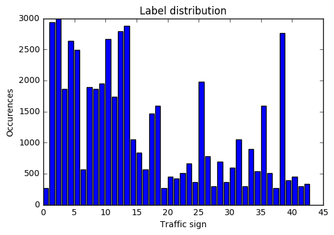

```python
### Data exploration visualization goes here.
### Feel free to use as many code cells as needed.

import collections
import matplotlib.pyplot as plt

#---------------------------------
#distribution of classes
all_y = np.concatenate((y_train, y_test))

label_dist = collections.Counter(all_y)

labels, vals = zip(*label_dist.items())
indices = np.arange(len(labels))

plt.bar(indices, vals)
plt.title("Label distribution")
plt.ylabel("Occurences")
plt.xlabel("Traffic sign")
plt.show()
```

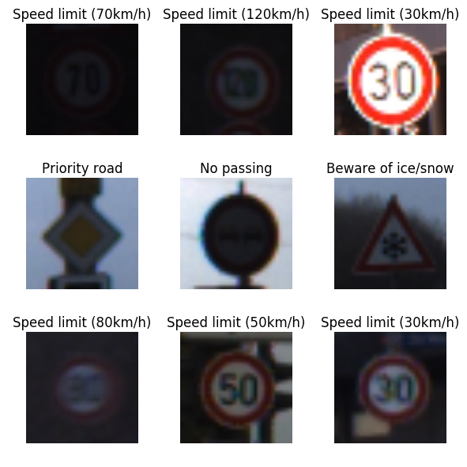

```python
#look at some random traffic signs

#function to create dictionary that pairs sign ids with sign names
def signs_dict():
    names = open("signnames.csv").readlines()[1:]
    stripped = [name.strip().split(",") for name in names]
    return dict([(int(id), name) for id, name in stripped])

#create dict
signs_dict = signs_dict()

#gets images and labels for 9 random signs
rand_sign_indices = np.random.randint(0, n_train, 9)
rand_signs = x_train[rand_sign_indices]
rand_labels = list(map(signs_dict.get, y_train[rand_sign_indices]))

#create plot
fig, axes = plt.subplots(nrows=3, ncols=3, figsize=(6, 6))
axes = axes.ravel()
fig.tight_layout()
for ax, img, label in zip(axes, rand_signs, rand_labels):
    ax.imshow(img)
    ax.set_title(label)
    ax.axis('off')

#show plot
plt.show()
```

## Step 2: Design and Test a Model Architecture

Design and implement a deep learning model that learns to recognize traffic signs. Train and test your model on the [German Traffic Sign Dataset](http://benchmark.ini.rub.de/?section=gtsrb&subsection=dataset).

There are various aspects to consider when thinking about this problem:

- Your model can be derived from a deep feedforward net or a deep convolutional network.
- Play around preprocessing techniques (normalization, rgb to grayscale, etc)
- Number of examples per label (some have more than others).
- Generate fake data.

Here is an example of a [published baseline model on this problem](http://yann.lecun.com/exdb/publis/pdf/sermanet-ijcnn-11.pdf). It's not required to be familiar with the approach used in the paper but, it's good practice to try to read papers like these.

### Implementation

Use the code cell (or multiple code cells, if necessary) to implement the first step of your project. Once you have completed your implementation and are satisfied with the results, be sure to thoroughly answer the questions that follow.

```python
import cv2
from sklearn import preprocessing

#normalizing function to get 0-1 range and 0 variance
def normalize(img):
    normalized_img = cv2.normalize(img, None, 0.0, 0.1, norm_type=cv2.NORM_MINMAX, dtype=cv2.CV_32F)
    return normalized_img

#blur function to increase
def gaussian_blur(img):
    """Applies a Gaussian Noise kernel"""
    kernel_size = 3
    return cv2.GaussianBlur(img, (kernel_size, kernel_size), 0)

#shuffle training data
def randomize(features, labels):
    permutation = np.random.permutation(labels.shape[0])
    shuffled_features = features[permutation,:,:,:]
    shuffled_labels = labels[permutation]
    return shuffled_features, shuffled_labels

x_train, y_train = randomize(x_train, y_train)

#apply preprocessing functions
x_train_processed = np.empty((len(x_train), image_shape[0], image_shape[1], 3))
x_test_processed = np.empty((len(x_test), image_shape[0], image_shape[1], 3))
for i in range(len(x_train)):
    x_train_processed[i] = normalize(gaussian_blur(x_train[i]))
for i in range(len(x_test)):
    x_test_processed[i] = normalize(gaussian_blur(x_test[i]))


#one hot encoding (change y dim to (obs, label))
#also change to float32, so it can be multiplied against the features in tf, which are float32
encoder = preprocessing.LabelBinarizer()
encoder.fit(y_train)
y_train_encoded = encoder.transform(y_train).astype(np.float32)
y_test_encoded = encoder.transform(y_test).astype(np.float32)
```

### Question 1

*Describe the techniques used to preprocess the data.*

```python
from sklearn.model_selection import train_test_split

#splitting test into test and validation and shuffling
x_test_2, x_valid_2, y_test_2, y_valid_2 = train_test_split(x_test_processed, y_test_encoded, test_size = 0.5, random_state = 0)

#shuffling training
indices = np.arange(len(x_train_processed -1))
np.random.shuffle(indices)
x_train_2 = x_train_processed[indices]
y_train_2 = y_train_encoded[indices]

print("X train: " + str(len(x_train_2)))
print("Y train: " + str(len(y_train_2)))

print("X valid: " + str(len(x_valid_2)))
print("Y valid: " + str(len(y_valid_2)))

print("X test: " + str(len(x_test_2)))
print("Y test: " + str(len(y_test_2)))
```

```
X train: 39209
Y train: 39209
X valid: 6315
Y valid: 6315
X test: 6315
Y test: 6315
```

### Question 2

*Describe how you set up the training, validation and testing data for your model. If you generated additional data, why?*

**Answer**

I kept the training data the same size because it makes up around 75% of the total data. This is a good fraction - it is good to use most of your data on training. I then randomized the testing data and split it into 2 equal parts - a new testing data set and a validation set.

```python
### Define your architecture here.

#import libraries
import tensorflow as tf

#params
learning_rate = 0.01
batch_size = 64
training_epochs = 20
n_classes = 43
filter_size = 5
dropout = 0.8

#graph input
x = tf.placeholder("float", [None, 32, 32, 3])
y = tf.placeholder("float", [None, n_classes])
keep_prob = tf.placeholder(tf.float32)

#layer widths
layer_width = {
    'layer_1': 32,
    'layer_2': 64,
    'layer_3': 128,
    'fully_connected': 512
}

#conv wrapper
def conv2d(x, W, b, strides=1):
    x = tf.nn.conv2d(x, W, strides=[1, strides, strides, 1], padding='SAME')
    x = tf.nn.bias_add(x, b)
    return tf.nn.relu(x)

#pooling wrapper
def maxpool2d(x, k=2):
    return tf.nn.max_pool(x, ksize=[1,k,k,1],strides=[1,k,k,1],padding='SAME')


#weights and biases
weights = {
    'layer_1': tf.Variable(tf.truncated_normal(
        [filter_size, filter_size, 3, layer_width['layer_1']], stddev=0.05)),
    'layer_2': tf.Variable(tf.truncated_normal(
        [filter_size, filter_size, layer_width['layer_1'], layer_width['layer_2']], stddev=0.05)),
    'layer_3': tf.Variable(tf.truncated_normal(
        [filter_size, filter_size, layer_width['layer_2'], layer_width['layer_3']], stddev=0.05)),
    'fully_connected': tf.Variable(tf.truncated_normal(
        [4*4*128, layer_width['fully_connected']], stddev=0.05)),
    'out': tf.Variable(tf.truncated_normal(
            [layer_width['fully_connected'], n_classes], stddev=0.05))
}


biases = {
    'layer_1': tf.Variable(tf.zeros(layer_width['layer_1'])),
    'layer_2': tf.Variable(tf.zeros(layer_width['layer_2'])),
    'layer_3': tf.Variable(tf.zeros(layer_width['layer_3'])),
    'fully_connected': tf.Variable(tf.zeros(layer_width['fully_connected'])),
    'out': tf.Variable(tf.zeros(n_classes))
}


#model
def conv_net(x, weights, biases, dropout):
    #layer 1 - 32*32*3 to 16*16*32
    conv1 = conv2d(x, weights['layer_1'], biases['layer_1'])
    conv1 = maxpool2d(conv1)

    #layer 2 - 16*16*32 to 8*8*64
    conv2 = conv2d(conv1, weights['layer_2'], biases['layer_2'])
    conv2 = maxpool2d(conv2)

    #layer 3 - 8*8*32 to 4*4*128
    conv3 = conv2d(conv2, weights['layer_3'], biases['layer_3'])
    conv3 = maxpool2d(conv3)

    #fully connected - 4*4*128 to 512
    #reshape first
    fc1 = tf.reshape(conv3,[-1,weights['fully_connected'].get_shape().as_list()[0]])
    fc1 = tf.add(tf.matmul(fc1, weights['fully_connected']),biases['fully_connected'])
    fc1 = tf.nn.relu(fc1)

    #apply dropout
    fc1 = tf.nn.dropout(fc1, dropout)

    #output layer - 512 to 43
    out = tf.add(tf.matmul(fc1, weights['out']), biases['out'])
    return out
```

### Question 3

*What does your final architecture look like? (Type of model, layers, sizes, connectivity, etc.) For reference on how to build a deep neural network using TensorFlow, see Deep Neural Network in TensorFlow from the classroom.*

```python
#construct model
logits = conv_net(x, weights, biases, keep_prob)
softmax = tf.nn.softmax(logits)
predictions = tf.argmax(softmax,1)

#loss and optimizer
cost = tf.reduce_mean(tf.nn.softmax_cross_entropy_with_logits(logits, y))
optimizer = tf.train.GradientDescentOptimizer(learning_rate=learning_rate).minimize(cost)

#evaluate model
correct_prediction = tf.equal(tf.argmax(logits, 1), tf.argmax(y, 1))
accuracy = tf.reduce_mean(tf.cast(correct_prediction, "float"))

#run session
sess = tf.Session()
sess.run(tf.initialize_all_variables())

#training cycle
for epoch in range(training_epochs):
    for offset in range(0, len(x_train_2), batch_size):

        # Get a batch of training features and labels
        end = offset + batch_size
        batch_features = x_train_2[offset:end]
        batch_labels = y_train_2[offset:end]

        # Run optimization op (backprop) and cost op (to get loss value)
        sess.run(optimizer, feed_dict={x: batch_features, y: batch_labels, keep_prob: dropout})

        # Display logs per epoch step
        loss, acc = sess.run([cost, accuracy], feed_dict={x: batch_features, y: batch_labels, keep_prob: 1.})
        print("Epoch:", epoch, "Offset:", offset, "Loss:", loss, "Accuracy:", acc)


print("Optimization Finished!")
print("Testing Accuracy:", sess.run(accuracy, feed_dict={x: x_test_2, y: y_test_2, keep_prob:1.}))
print("Validation Accuracy:", sess.run(accuracy, feed_dict={x: x_valid_2, y: y_valid_2, keep_prob:1.}))
```

[output not shown]

[output cut: 7473 more lines]

[output not shown]

```python
print("Testing Accuracy:", sess.run(accuracy, feed_dict={x: x_test_2, y: y_test_2, keep_prob:1.}))
print("Validation Accuracy:", sess.run(accuracy, feed_dict={x: x_valid_2, y: y_valid_2, keep_prob:1.}))
```

```
Testing Accuracy: 0.79034
Validation Accuracy: 0.790499
```

### Question 4

*How did you train your model? (Type of optimizer, batch size, epochs, hyperparameters, etc.)*

**Answer:**

I trained the model over 20 epochs, a batch size of 64, and a learning rate of 0.01.

Training accuracy: 100%

Validation accuracy: 79%

### Question 5

*What approach did you take in coming up with a solution to this problem?*

**Answer:**

I started with a simple 1-layer neural network and trained it on a small dataset, to make sure it works and to also ensure that I could reach an accuracy of 1 (I didn't worry about overfitting yet). Then I added complexity (more layers, dropout, etc.) whenever such changes led to increases in accuracy.

The model was always trained on the training set and accuracy measured on the testing set. Once I was happy with the overall model architecture, I fine tuned parameters and hyperparameters depending on their impact on testing accuracy. Lastly, I used the validation set to determine final accuracy.

## Step 3: Test a Model on New Images

Take several pictures of traffic signs that you find on the web or around you (at least five), and run them through your classifier on your computer to produce example results. The classifier might not recognize some local signs but it could prove interesting nonetheless.

You may find `signnames.csv` useful as it contains mappings from the class id (integer) to the actual sign name.

### Implementation

Use the code cell (or multiple code cells, if necessary) to implement the first step of your project. Once you have completed your implementation and are satisfied with the results, be sure to thoroughly answer the questions that follow.

```
Predictions (Classes): [10 13 17 38  5 11]
Predictions (Labels): ['No passing for vechiles over 3.5 metric tons', 'Yield', 'No entry', 'Keep right', 'Speed limit (80km/h)', 'Right-of-way at the next intersection']
```

[figure not shown]

```python
#image locations
img_names = ['image_1', 'image_2', 'image_3', 'image_4', 'image_5', 'image_6']
img_names = [pwd + "/traffic-signs-data/new_images/" + img_name + '.jpg' for img_name in img_names]


#reading images
def read_images(img_names):
    images = []
    for img_name in img_names:
        image = plt.imread(img_name)
        images.append(image)
    return images

images = read_images(img_names)

#processesing_images
def process_images(images):
    processed_images = np.zeros((6, 32, 32, 3))
    for i, img in enumerate(images):
        img_processed = normalize(gaussian_blur(cv2.resize(img, (32,32))))
        processed_images[i] = img_processed
    return processed_images

processed_images = process_images(images)


# set up y array
y_labels = np.zeros(shape = (6,43))
y_labels[0][14] = 1
y_labels[0][13] = 1
y_labels[0][17] = 1
y_labels[0][3] = 1
y_labels[0][28] = 1

#get logits, cost, and predictions
softmax_2, predictions_2 = sess.run([softmax, predictions], feed_dict={x: processed_images, y: y_labels, keep_prob: 1.})

#get labels from classes
labels = [signs_dict[prediction] for prediction in predictions_2]

#print loss
print("Predictions (Classes):", predictions_2)
print("Predictions (Labels):", labels)

#plot images with predicated labels
fig, axes = plt.subplots(nrows=2, ncols=3, figsize=(6, 6))
axes = axes.ravel()
fig.tight_layout()
for ax, img, label in zip(axes, images, labels):
    ax.imshow(img)
    ax.set_title(label)
    ax.axis('off')
plt.show()
```

### Question 6

*Choose five candidate images of traffic signs and provide them in the report. Are there any particular qualities of the image(s) that might make classification difficult? It would be helpful to plot the images in the notebook.*

**Answer:**

Reasons for low accuracy are:

- New images didn't have a standard size. Training and test was done on (32,32) images so, in order to run the model on these new images, one of the image processing steps was resizing. Since the aspect ratio of the images wasn't always 1:1, images got squeezed or stretched.
- In new images the signs didn't always fill the images the way they did on training/testing data. For instance, for the keep left sign, the sign is located in the top half of the image. To improve the model, one step could be to first apply a region-of-interest filter.
- Some of the new images (for example, the stop sign), are seen from an angle. The training data didn't have many samples like this. As a solution, I could've generated new data by transforming existing data and applying a rotation/warp effect.

### Question 7

*Is your model able to perform equally well on captured pictures or a live camera stream when compared to testing on the dataset?*

**Answer**

No, the model performs significantly worse on real-life images. I got an accuracy of 33%% (2/6), compared to 79% on the validation set.

```python
#define structure for top_k
top_five_str = tf.nn.top_k(softmax_2, k=5, sorted=True, name=None)

#get top 5 for processed images
top_five = sess.run([top_five_str], feed_dict={x: processed_images})

for i in range(0,6):
    labels = [signs_dict[j] for j in top_five[0][1][i]]
    print(labels)

print(top_five)
```

```
['No passing for vechiles over 3.5 metric tons', 'Stop', 'Right-of-way at the next intersection', 'Speed limit (100km/h)', 'Priority road']
['Yield', 'Speed limit (30km/h)', 'Bicycles crossing', 'Speed limit (100km/h)', 'Speed limit (20km/h)']
['No entry', 'Stop', 'Bumpy road', 'Yield', 'Bicycles crossing']
['Keep right', 'Turn left ahead', 'Yield', 'End of all speed and passing limits', 'End of no passing']
['Speed limit (80km/h)', 'Speed limit (60km/h)', 'Speed limit (100km/h)', 'Speed limit (50km/h)', 'No passing']
['Right-of-way at the next intersection', 'Beware of ice/snow', 'Speed limit (100km/h)', 'Slippery road', 'Road narrows on the right']
[TopKV2(values=array([[  9.60224211e-01,   3.78861874e-02,   6.72530849e-04,
          6.50339120e-04,   4.82487842e-04],
       [  6.28874719e-01,   2.11107582e-01,   4.58767861e-02,
          2.65339818e-02,   2.14516819e-02],
       [  9.94006991e-01,   5.99249359e-03,   3.23676119e-07,
          1.77944386e-07,   4.10282830e-09],
       [  9.91910040e-01,   4.99859359e-03,   3.08612105e-03,
          4.00619001e-06,   3.88895245e-07],
       [  9.14324701e-01,   7.54981488e-02,   6.82239607e-03,
          1.72589999e-03,   7.95257918e-04],
       [  8.90543103e-01,   1.08999453e-01,   4.04276070e-04,
          1.63942441e-05,   1.25964707e-05]], dtype=float32), indices=array([[10, 14, 11,  7, 12],
       [13,  1, 29,  7,  0],
       [17, 14, 22, 13, 29],
       [38, 34, 13, 32, 41],
       [ 5,  3,  7,  2,  9],
       [11, 30,  7, 23, 24]], dtype=int32))]
```

### Question 8

*Use the model's softmax probabilities to visualize the **certainty** of its predictions, [`tf.nn.top_k`](https://www.tensorflow.org/versions/r0.11/api_docs/python/nn.html#top_k) could prove helpful here. Which predictions is the model certain of? Uncertain? If the model was incorrect in its initial prediction, does the correct prediction appear in the top k? (k should be 5 at most)*

For the 4 cases in which the model prediction was false, the right prediction was the 2nd highest probability prediction for 2 of the cases.

For the remaining 2 predictions, the correct prediction didn't show up in the top 5.

### Question 9

*If necessary, provide documentation for how an interface was built for your model to load and classify newly-acquired images.*

**Answer:**

I created a list of the image names and used a list comprehension function to turn this list into another list that had the complete file path (prepended the working diretory and appended the extension). Then I defined a read function that loops throught the file path list, reads each image, and adds it to an array. Then I defined a second preprocessing function that processes the images the same way I processed the training and testing data (blurring and normalizing). I also included an extra step for resizing because not all images were the same size.